# Instructor Group Predictions

#### CBS Sports

This week we beat or tied 7 of 8 CBS Sports’ Experts.

For the season we are currently beating or tied with 7 of 8 CBS Sports’ Experts.

#### ESPN

We also beat or tied 9 of 9 ESPN Experts.

For the season we are currently beating or tied with 6 of 9 ESPN Experts.

### Win percentage for the week

[interactive chart not shown]

### Season Win Percentage

[interactive chart not shown]

### Games Correct

169

### Games Picked

252

### Number of predictions

10

This Week's Predictions

Week 17

| Game | Prediction | Winner | Correct | Correct Votes | Correct Percent |
| --- | --- | --- | --- | --- | --- |
| 1 | Dallas Cowboys | New York Giants | No | 4 | 0.4 |
| 2 | Baltimore Ravens | Baltimore Ravens | Yes | 10 | 1.0 |
| 3 | Tampa Bay Buccaneers | Tampa Bay Buccaneers | Yes | 10 | 1.0 |
| 4 | Buffalo Bills | Buffalo Bills | Yes | 10 | 1.0 |
| 5 | Minnesota Vikings | Minnesota Vikings | Yes | 10 | 1.0 |
| 6 | Pittsburgh Steelers | Cleveland Browns | No | 4 | 0.4 |
| 7 | New England Patriots | New England Patriots | Yes | 8 | 0.8 |
| 8 | Tennessee Titans | Tennessee Titans | Yes | 10 | 1.0 |
| 9 | Seattle Seahawks | Seattle Seahawks | Yes | 10 | 1.0 |
| 10 | Green Bay Packers | Green Bay Packers | Yes | 7 | 0.7 |
| 11 | Los Angeles Rams | Los Angeles Rams | Yes | 9 | 0.9 |
| 12 | Indianapolis Colts | Indianapolis Colts | Yes | 10 | 1.0 |
| 13 | Kansas City Chiefs | Los Angeles Chargers | No | 1 | 0.1 |
| 14 | New Orleans Saints | New Orleans Saints | Yes | 9 | 0.9 |
| 15 | Las Vegas Raiders | Las Vegas Raiders | Yes | 9 | 0.9 |
| 16 | Washington Football Team | Washington Football Team | Yes | 6 | 0.6 |

[interactive chart not shown]

# Instructor Individual Predictions

#### Best Picks of the Week.

Kevin Cummiskey, Tina Hartley

#### Best Season Correct Percentage

James Starling

#### Best Adjusted Season Correct Percentage

Kevin Cummiskey

- Adjusted season percentage accounts for the number of weeks picked.

## row

### Individual Table

Individual Results

Week 17

Name

Weekly # Correct

Percent

Weeks Picked

Season Percent

Adj Season Percent

Season Trend

Week 1

Week 2

Week 3

Week 4

Week 5

Week 6

Week 7

Week 8

Week 9

Week 10

Week 11

Week 12

Week 13

Week 14

Week 15

Week 16

Week 17

Kevin Cummiskey

13

11

9

9

10

7

9

5

10

9

7

12

10

10

12

10

14

0.8750

17

0.6627

0.6627

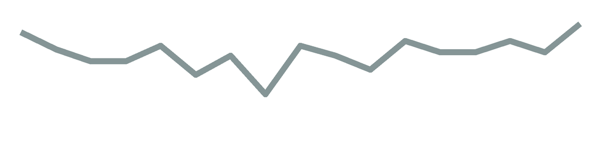

Tina Hartley

9

11

10

8

8

9

9

7

3

8

6

10

9

9

12

10

14

0.8750

17

0.6032

0.6032

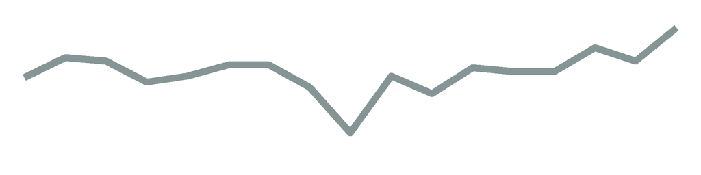

Gregory Minetos

9

14

10

12

8

8

12

7

10

7

7

11

9

9

12

8

13

0.8125

17

0.6587

0.6587

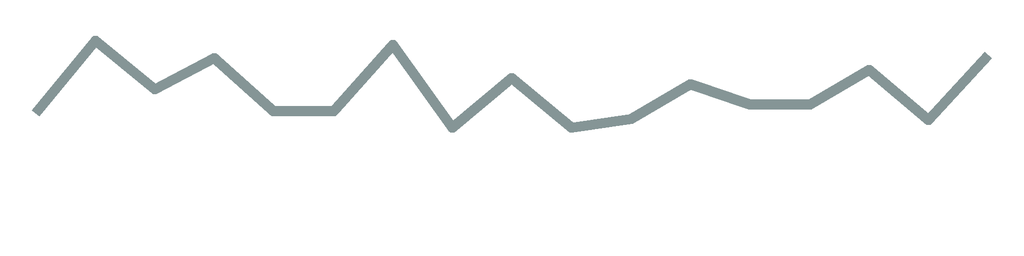

Gabriel Costa

9

12

6

9

10

7

9

7

10

10

9

NA

11

8

9

10

13

0.8125

16

0.6314

0.5943

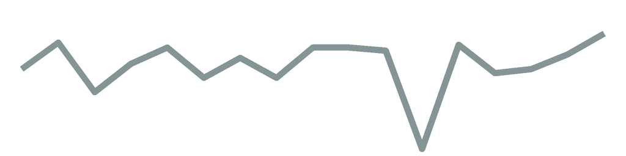

Frank Czerniakowski

7

13

10

9

8

6

9

6

11

5

9

11

9

12

NA

10

13

0.8125

16

0.6271

0.5902

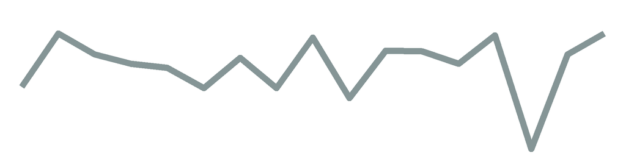

Blake Schwartz

10

9

10

10

10

9

9

6

5

8

7

9

11

10

11

11

13

0.8125

17

0.6270

0.6270

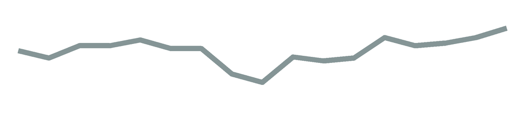

Eric Swenson

4

8

10

9

9

8

9

8

7

8

8

10

11

9

12

11

13

0.8125

17

0.6111

0.6111

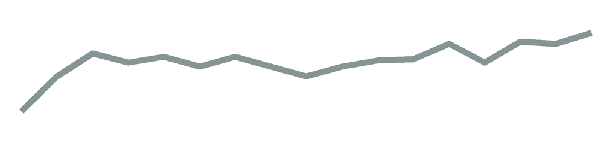

Josephine Cammack

9

11

12

10

9

9

11

7

6

8

NA

9

12

11

12

NA

12

0.7500

15

0.6607

0.5830

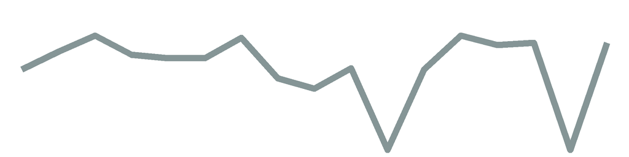

Daniel Baller

11

10

10

9

9

5

8

9

11

10

8

11

11

11

10

11

12

0.7500

17

0.6587

0.6587

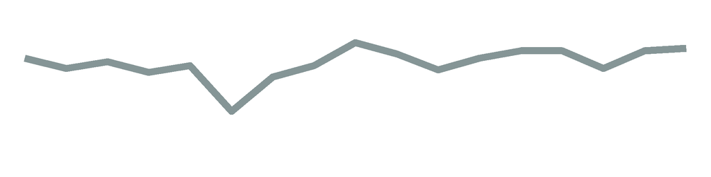

Shane Clark

10

14

9

9

9

9

10

NA

11

7

7

12

10

11

NA

NA

10

0.6250

14

0.6667

0.5490

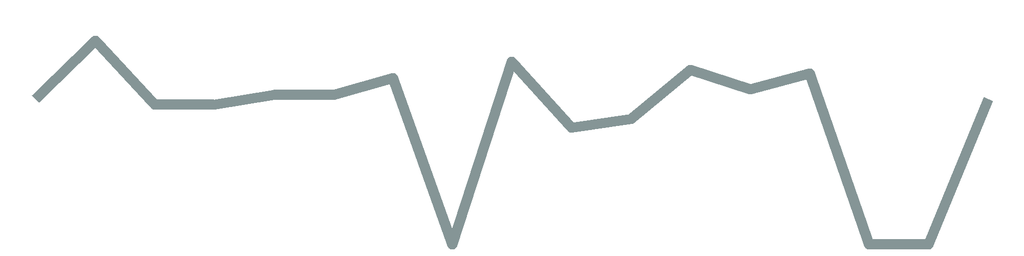

James Starling

15

12

9

12

10

NA

11

8

10

10

6

11

11

7

10

14

NA

0.0000

15

0.7027

0.6200

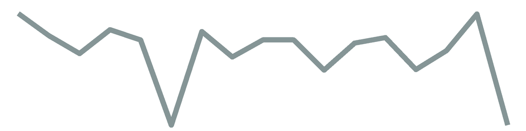

Daniel Richardson

13

11

10

10

8

NA

8

NA

NA

NA

NA

NA

NA

NA

NA

NA

NA

0.0000

6

0.6667

0.2353

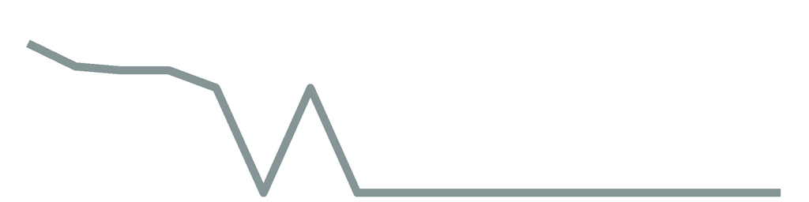

James Pleuss

9

12

10

12

7

8

10

9

9

10

7

10

12

12

11

9

NA

0.0000

16

0.6653

0.6262

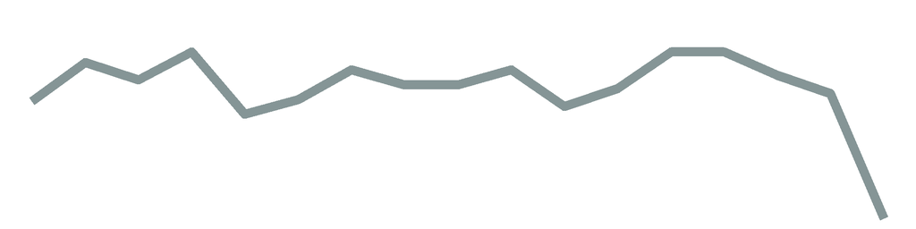

Michael Prokos

9

12

9

8

11

10

9

7

9

9

7

10

11

12

12

9

NA

0.0000

16

0.6525

0.6141

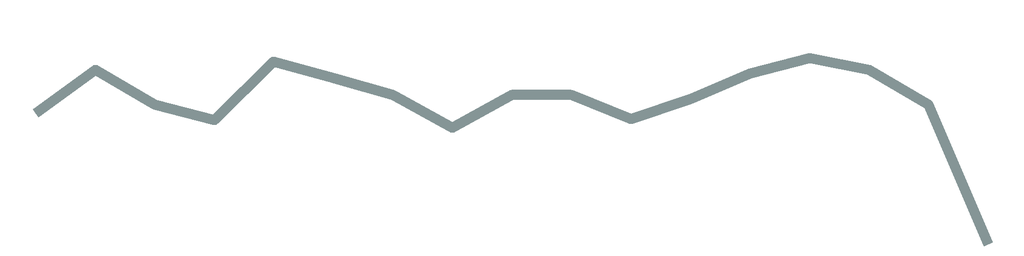

Margaret Wieczorek

11

14

9

9

8

NA

10

8

9

8

7

8

11

11

12

NA

NA

0.0000

14

0.6522

0.5371

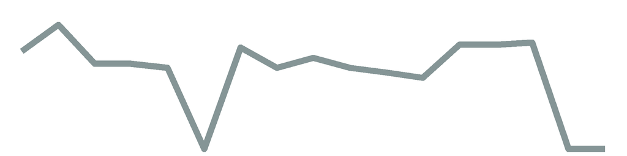

Travis Russell

11

8

8

11

10

10

10

8

NA

NA

7

NA

NA

NA

NA

NA

NA

0.0000

9

0.6336

0.3354

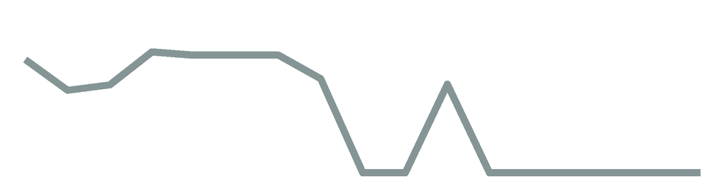

John Kearby

9

11

6

9

9

8

12

6

9

10

6

10

11

9

11

10

NA

0.0000

16

0.6186

0.5822

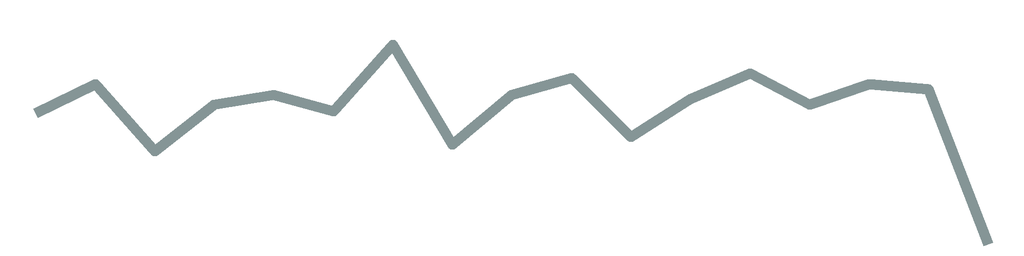

Nicholas Reisweber

9

10

10

8

10

7

8

8

10

9

6

14

9

8

9

11

NA

0.0000

16

0.6186

0.5822

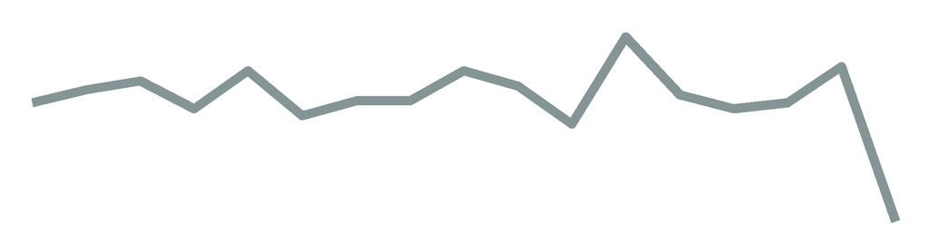

Welvin Lucero

9

11

9

10

NA

NA

11

8

NA

8

5

NA

NA

10

NA

NA

NA

0.0000

9

0.6136

0.3248

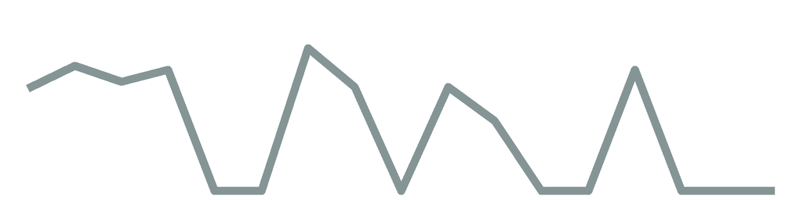

Kevin Quigley

8

8

9

10

10

8

8

6

8

7

9

10

NA

NA

11

9

NA

0.0000

14

0.5874

0.4837

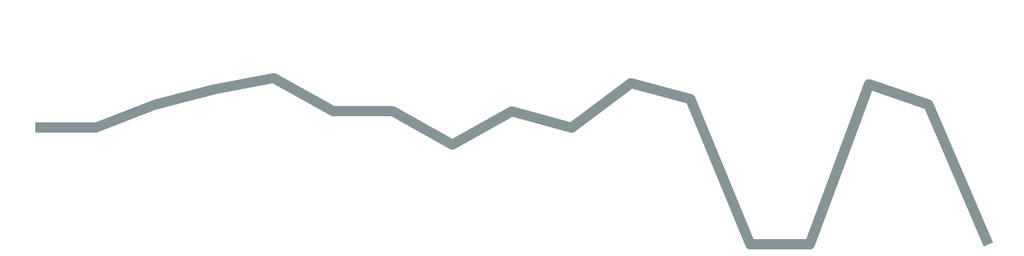

Andrew Lee

9

10

8

NA

NA

NA

NA

NA

NA

NA

NA

NA

NA

NA

NA

NA

NA

0.0000

3

0.5745

0.1014

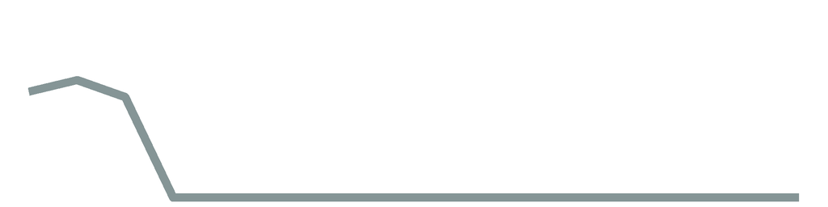

Timothy Moore

10

11

8

9

7

9

7

7

7

NA

NA

NA

9

10

8

NA

NA

0.0000

12

0.5730

0.4045

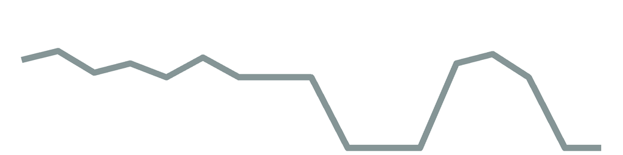

### Individual Plots

[interactive chart not shown]

# Cadet Group Predictions

#### CBS Sports

This week we beat or tied 7 of 8 CBS Sports’ Experts.

For the season we are currently beating or tied with 7 of 8 CBS Sports’ Experts.

#### ESPN

We also beat or tied 9 of 9 ESPN Experts.

For the season we are currently beating or tied with 6 of 9 ESPN Experts.

### Win percentage for the week

[interactive chart not shown]

### Season Win Percent

[interactive chart not shown]

### Games Correct

169

### Predictions

4

This Week's MA376 Predictions

Week 17

| Game | Prediction | Winner | Correct | Correct Votes | Correct Percent |
| --- | --- | --- | --- | --- | --- |
| 1 | Dallas Cowboys | New York Giants | No | 0 | 0.00 |
| 2 | Baltimore Ravens | Baltimore Ravens | Yes | 4 | 1.00 |
| 3 | Tampa Bay Buccaneers | Tampa Bay Buccaneers | Yes | 4 | 1.00 |
| 4 | Buffalo Bills | Buffalo Bills | Yes | 3 | 0.75 |
| 5 | Minnesota Vikings | Minnesota Vikings | Yes | 4 | 1.00 |
| 6 | Pittsburgh Steelers | Cleveland Browns | No | 0 | 0.00 |
| 7 | New England Patriots | New England Patriots | Yes | 4 | 1.00 |
| 8 | Tennessee Titans | Tennessee Titans | Yes | 4 | 1.00 |
| 9 | Seattle Seahawks | Seattle Seahawks | Yes | 4 | 1.00 |
| 10 | Green Bay Packers | Green Bay Packers | Yes | 4 | 1.00 |
| 11 | Los Angeles Rams | Los Angeles Rams | Yes | 3 | 0.75 |
| 12 | Indianapolis Colts | Indianapolis Colts | Yes | 4 | 1.00 |
| 13 | Kansas City Chiefs | Los Angeles Chargers | No | 1 | 0.25 |
| 14 | New Orleans Saints | New Orleans Saints | Yes | 4 | 1.00 |
| 15 | Las Vegas Raiders | Las Vegas Raiders | Yes | 4 | 1.00 |
| 16 | Washington Football Team | Washington Football Team | Yes | 3 | 0.75 |

[interactive chart not shown]

# Cadet Individual Predictions

#### Best Picks of the Week.

Caroline Swenson, Joshua Loyd

#### Best Season Correct Percentage

Thomas Bizub

#### Best Adjusted Season Correct Percentage

John White

- Adjusted season percentage accounts for the number of weeks picked.

### Cadet Individual Table

MA376 Individual Results

Week 17

Name

Weekly # Correct

Percent

Weeks Picked

Season Percent

Adj Season Percent

Season Trend

Week 1

Week 2

Week 3

Week 4

Week 5

Week 6

Week 7

Week 8

Week 9

Week 10

Week 11

Week 12

Week 13

Week 14

Week 15

Week 16

Week 17

Caroline Swenson

8

12

11

13

7

8

10

NA

8

9

8

NA

12

11

12

8

13

0.8125

15

0.6757

0.5962

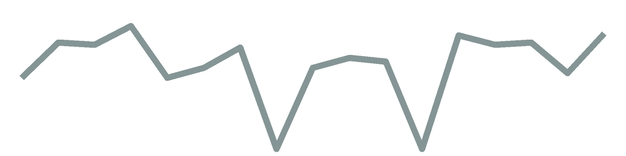

Joshua Loyd

11

9

8

NA

6

9

NA

6

10

8

NA

10

9

11

12

12

13

0.8125

14

0.6381

0.5255

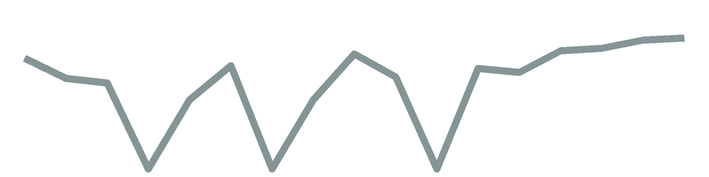

John White

10

11

10

8

12

9

11

6

9

9

8

10

8

11

10

10

12

0.7500

17

0.6508

0.6508

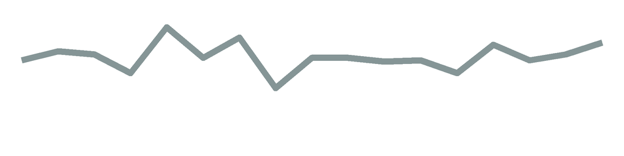

Sydney Shannon

10

9

8

9

8

7

9

5

8

10

8

10

11

10

11

12

12

0.7500

17

0.6230

0.6230

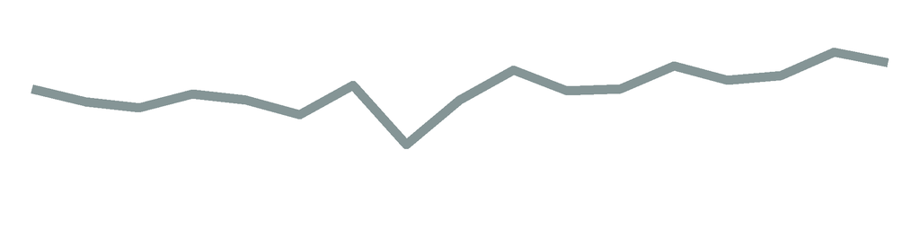

Thomas Bizub

10

14

8

11

8

9

10

8

10

12

9

11

9

10

NA

NA

NA

0.0000

14

0.6780

0.5584

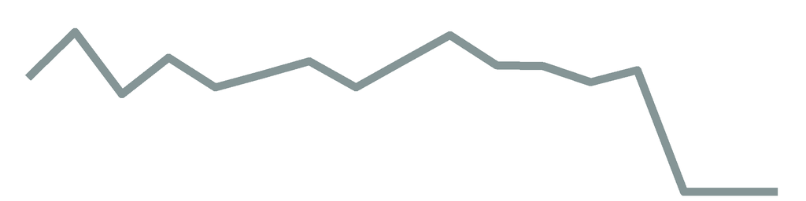

Amadou Bah

9

NA

NA

NA

NA

NA

NA

NA

NA

NA

NA

NA

NA

NA

NA

12

NA

0.0000

2

0.6774

0.0797

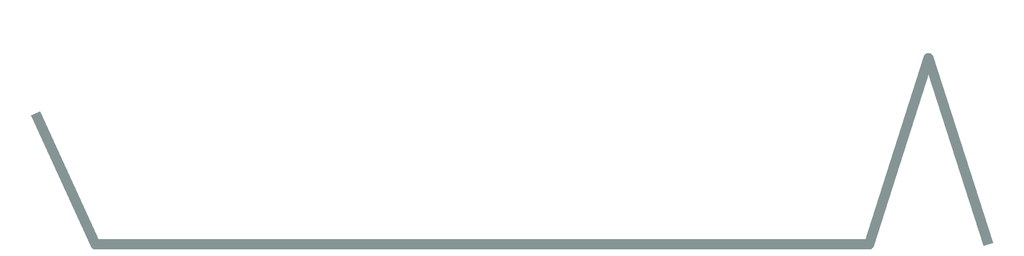

Kieran Place

12

11

8

NA

10

10

9

NA

NA

NA

NA

NA

NA

NA

NA

NA

NA

0.0000

6

0.6742

0.2380

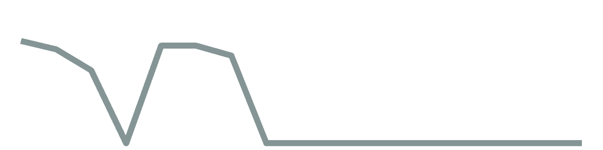

Luca Testa

NA

NA

10

NA

NA

NA

NA

NA

NA

NA

NA

NA

NA

NA

NA

NA

NA

0.0000

1

0.6667

0.0392

[figure not shown]

Laurence Dowd

10

10

10

9

10

NA

12

NA

10

8

7

NA

10

NA

NA

NA

NA

0.0000

10

0.6575

0.3868

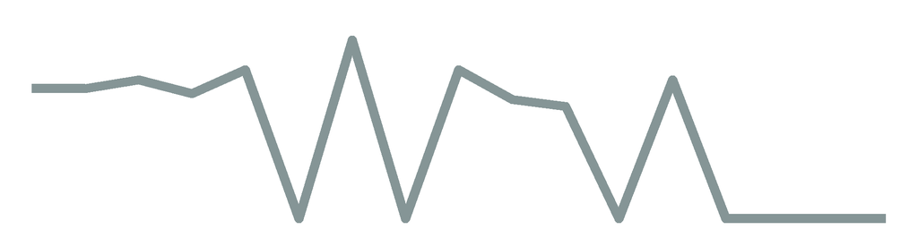

Jonathan Kemp

10

10

NA

NA

11

10

11

7

8

6

8

12

8

9

NA

NA

NA

0.0000

12

0.6286

0.4437

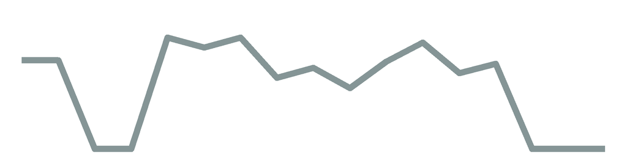

Paige Lennon

NA

NA

NA

11

10

8

11

8

6

8

6

9

11

10

11

NA

NA

0.0000

12

0.6264

0.4422

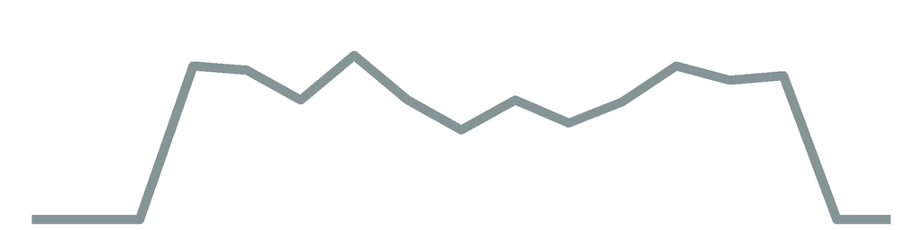

Zakai Bufkin

8

11

7

9

8

10

9

7

9

9

NA

10

NA

NA

NA

12

NA

0.0000

12

0.6158

0.4347

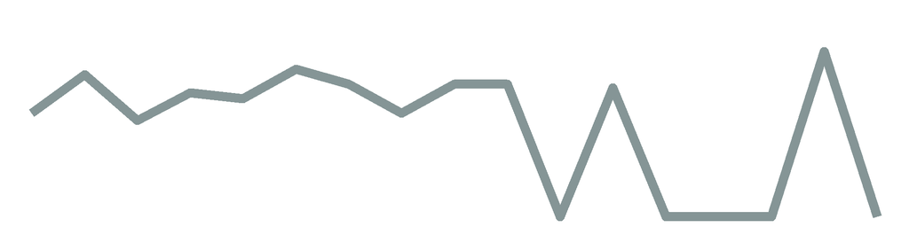

Christopher Erb

9

9

7

11

9

11

8

11

10

9

5

10

9

8

NA

NA

NA

0.0000

14

0.6146

0.5061

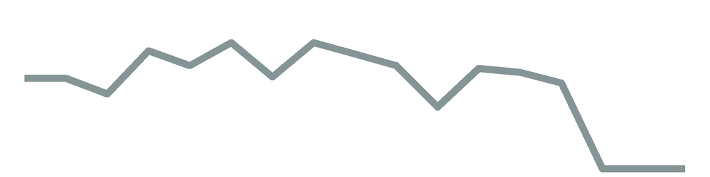

Gabriela Peralta

11

8

9

NA

8

8

10

6

NA

8

6

10

12

NA

12

NA

NA

0.0000

12

0.6102

0.4307

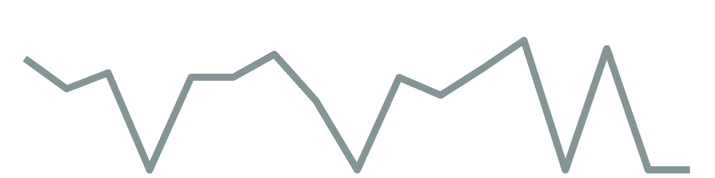

Victor Olawale-Apanpa

8

NA

10

NA

10

NA

10

7

7

9

6

11

10

NA

NA

NA

NA

0.0000

10

0.6069

0.3570

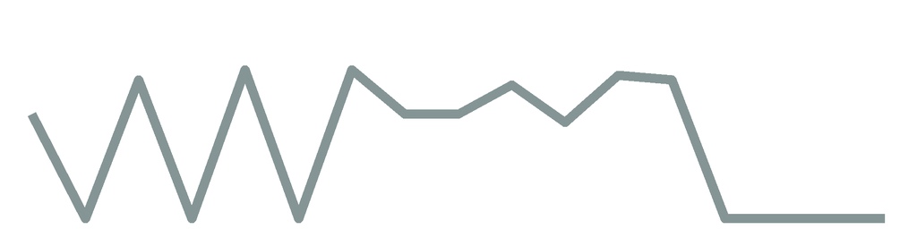

Sidney Cash

10

10

NA

10

NA

8

8

7

11

8

5

10

10

8

NA

NA

NA

0.0000

12

0.5966

0.4211

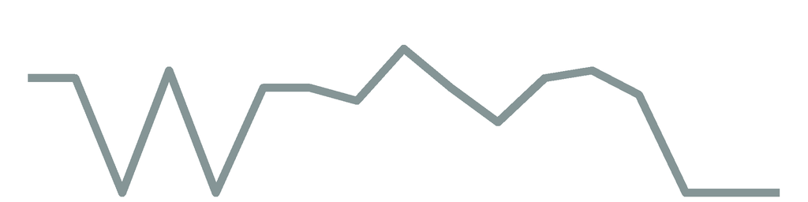

Cameron Patterson

11

9

8

NA

NA

NA

NA

NA

NA

NA

NA

NA

NA

NA

NA

NA

NA

0.0000

3

0.5957

0.1051

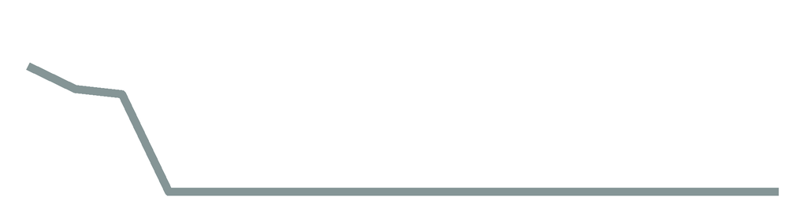

Joshua Gilliard

9

8

9

10

10

7

10

7

5

8

NA

10

10

NA

NA

NA

NA

0.0000

12

0.5819

0.4108

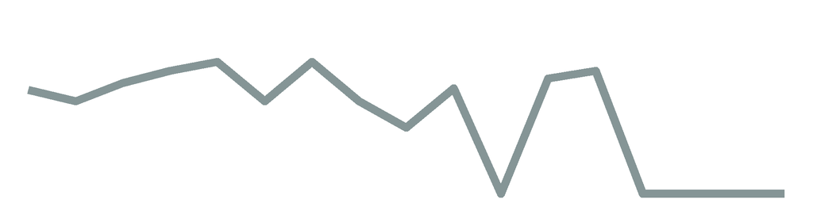

Margaret Williams

9

NA

NA

NA

NA

NA

NA

NA

NA

NA

NA

NA

NA

NA

NA

NA

NA

0.0000

1

0.5625

0.0331

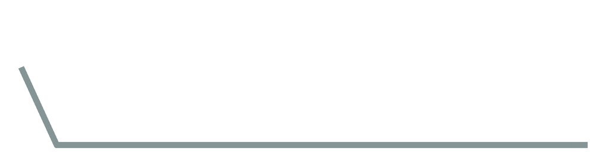

Logan Kauina

9

NA

NA

NA

NA

NA

NA

NA

NA

NA

NA

NA

NA

NA

NA

NA

NA

0.0000

1

0.5625

0.0331

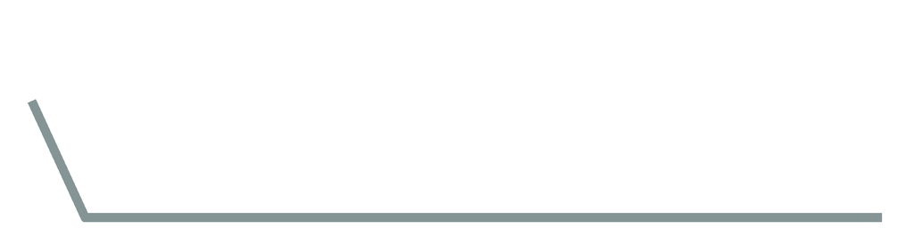

Caleb John

NA

9

NA

NA

NA

NA

NA

NA

NA

NA

NA

NA

NA

NA

NA

NA

NA

0.0000

1

0.5625

0.0331

[figure not shown]

Jay Hajost

11

7

10

NA

6

NA

NA

7

9

NA

NA

NA

NA

NA

NA

NA

NA

0.0000

6

0.5618

0.1983

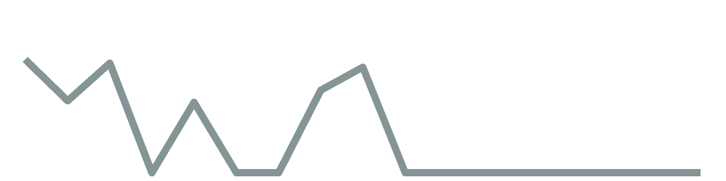

Ryan Jackovic

11

10

NA

7

7

8

8

7

NA

4

5

NA

12

10

NA

NA

NA

0.0000

11

0.5562

0.3599

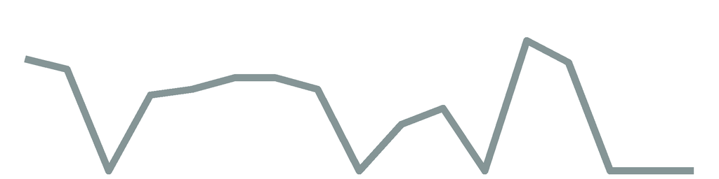

August Rannow

9

NA

NA

NA

7

NA

NA

NA

NA

NA

NA

NA

NA

NA

NA

NA

NA

0.0000

2

0.5333

0.0627

[figure not shown]

Peter Digenan

9

6

8

10

7

NA

NA

NA

NA

NA

NA

NA

NA

NA

NA

NA

NA

0.0000

5

0.5263

0.1548

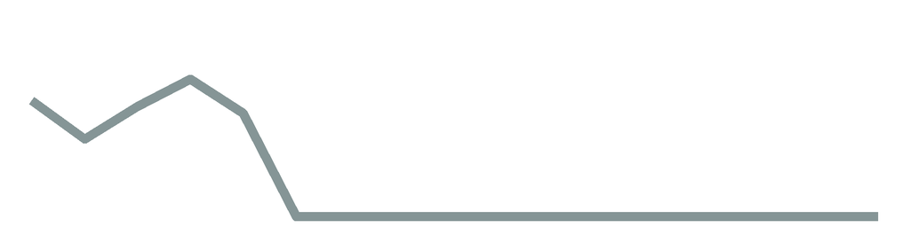

Caleb Doyle

9

NA

NA

NA

NA

NA

NA

6

NA

NA

NA

NA

NA

NA

NA

NA

NA

0.0000

2

0.5000

0.0588

[figure not shown]

Sydney Johnson

NA

NA

NA

NA

NA

NA

NA

6

NA

NA

NA

NA

NA

NA

NA

NA

NA

0.0000

1

0.4286

0.0252

[figure not shown]

### Cadet Individual Plots

[interactive chart not shown]

# Combined Predictions

#### CBS Sports

This week our combined predictions beat or tied 7 of 8 CBS Sports’ Experts.

For the season we are currently beating or tied with 7 of 8 CBS Sports’ Experts.

#### ESPN

Our combined predictions also beat or tied 9 of 9 ESPN Experts.

For the season our combined predictions are currently beating or tied with 6 of 9 ESPN Experts.

### Win percentage for the week

[interactive chart not shown]

### Season Win Percent

[interactive chart not shown]

### Games Correct

172

### Games Picked

255

### Number of Predictions

14

This Week's Combined Cadet and Instructor Predictions

Week 17

| Game | Prediction | Winner | Correct | Correct Votes | Correct Percent |
| --- | --- | --- | --- | --- | --- |
| 1 | Dallas Cowboys | New York Giants | No | 4 | 0.2857 |
| 2 | Baltimore Ravens | Baltimore Ravens | Yes | 14 | 1.0000 |
| 3 | Tampa Bay Buccaneers | Tampa Bay Buccaneers | Yes | 14 | 1.0000 |
| 4 | Buffalo Bills | Buffalo Bills | Yes | 13 | 0.9286 |
| 5 | Minnesota Vikings | Minnesota Vikings | Yes | 14 | 1.0000 |
| 6 | Pittsburgh Steelers | Cleveland Browns | No | 4 | 0.2857 |
| 7 | New England Patriots | New England Patriots | Yes | 12 | 0.8571 |
| 8 | Tennessee Titans | Tennessee Titans | Yes | 14 | 1.0000 |
| 9 | Seattle Seahawks | Seattle Seahawks | Yes | 14 | 1.0000 |
| 10 | Green Bay Packers | Green Bay Packers | Yes | 11 | 0.7857 |
| 11 | Los Angeles Rams | Los Angeles Rams | Yes | 12 | 0.8571 |
| 12 | Indianapolis Colts | Indianapolis Colts | Yes | 14 | 1.0000 |
| 13 | Kansas City Chiefs | Los Angeles Chargers | No | 2 | 0.1429 |
| 14 | New Orleans Saints | New Orleans Saints | Yes | 13 | 0.9286 |
| 15 | Las Vegas Raiders | Las Vegas Raiders | Yes | 13 | 0.9286 |
| 16 | Washington Football Team | Washington Football Team | Yes | 9 | 0.6429 |

[interactive chart not shown]

# Matched Predictions

### Win percentage for the week

[interactive chart not shown]

### Season Win Percent

[interactive chart not shown]

### Games Picked

219

### Season Games Correct

151

This Week's Matched Cadet and Instructor Predictions

Week 17

| Game | Prediction | Correct |
| --- | --- | --- |
| 1 | Dallas Cowboys | No |
| 2 | Baltimore Ravens | Yes |
| 3 | Tampa Bay Buccaneers | Yes |
| 4 | Buffalo Bills | Yes |
| 5 | Minnesota Vikings | Yes |
| 6 | Pittsburgh Steelers | No |
| 7 | New England Patriots | Yes |
| 8 | Tennessee Titans | Yes |
| 9 | Seattle Seahawks | Yes |
| 10 | Green Bay Packers | Yes |
| 11 | Los Angeles Rams | Yes |
| 12 | Indianapolis Colts | Yes |
| 13 | Kansas City Chiefs | No |
| 14 | New Orleans Saints | Yes |
| 15 | Las Vegas Raiders | Yes |
| 16 | Washington Football Team | Yes |

[interactive chart not shown]

````r
---
title: "2020 NFL Moneyline Picks"
output:
  flexdashboard::flex_dashboard:
    theme:
      version: 4
      bootswatch: solar
    orientation: rows
    vertical_layout: fill
    social: ["menu"]
    source_code: embed
    navbar:
      - { title: "Created by: Daniel Baller", icon: "fa-github", href: "https://github.com/danielpballer"  }
---


```{r setup, include=FALSE}
#    source_code: embed
library(flexdashboard)
library(tidyverse)
library(data.table)
library(formattable)
library(ggpubr)
library(ggrepel)
library(gt)
library(glue)
library(ggthemes)
library(hrbrthemes)
library(sparkline)
library(plotly)
library(htmlwidgets)
source("./Functions/functions2.R")

thematic::thematic_rmd(font = "auto")
```

```{r Reading in our picks files, include=FALSE}
week_1 = read_csv("./CSV_Data_Files/2020 NFL Week 1.csv")
week_2 = read_csv("./CSV_Data_Files/2020 NFL Week 2.csv")
week_3 = read_csv("./CSV_Data_Files/2020 NFL Week 3.csv")
week_4 = read_csv("./CSV_Data_Files/2020 NFL Week 4.csv")
week_5 = read_csv("./CSV_Data_Files/2020 NFL Week 5.csv")
week_6 = read_csv("./CSV_Data_Files/2020 NFL Week 6.csv")
week_7 = read_csv("./CSV_Data_Files/2020 NFL Week 7.csv")
week_8 = read_csv("./CSV_Data_Files/2020 NFL Week 8.csv")
week_9 = read_csv("./CSV_Data_Files/2020 NFL Week 9.csv")
week_10 = read_csv("./CSV_Data_Files/2020 NFL Week 10.csv")
week_11 = read_csv("./CSV_Data_Files/2020 NFL Week 11.csv")
week_12 = read_csv("./CSV_Data_Files/2020 NFL Week 12.csv")
week_13 = read_csv("./CSV_Data_Files/2020 NFL Week 13.csv")
week_14 = read_csv("./CSV_Data_Files/2020 NFL Week 14.csv")
week_15 = read_csv("./CSV_Data_Files/2020 NFL Week 15.csv")
week_16 = read_csv("./CSV_Data_Files/2020 NFL Week 16.csv")
week_17 = read_csv("./CSV_Data_Files/2020 NFL Week 17.csv")
cadet_wk1 = read_csv("./CSV_Data_Files/2020 NFL Week 1 MA206.csv")
cadet_wk2 = read_csv("./CSV_Data_Files/2020 NFL Week 2 MA206.csv")
cadet_wk3 = read_csv("./CSV_Data_Files/2020 NFL Week 3 MA206.csv")
cadet_wk4 = read_csv("./CSV_Data_Files/2020 NFL Week 4 MA206.csv")
cadet_wk5 = read_csv("./CSV_Data_Files/2020 NFL Week 5 MA206.csv")
cadet_wk6 = read_csv("./CSV_Data_Files/2020 NFL Week 6 MA206.csv")
cadet_wk7 = read_csv("./CSV_Data_Files/2020 NFL Week 7 MA206.csv")
cadet_wk8 = read_csv("./CSV_Data_Files/2020 NFL Week 8 MA206.csv")
cadet_wk9 = read_csv("./CSV_Data_Files/2020 NFL Week 9 MA206.csv")
cadet_wk10 = read_csv("./CSV_Data_Files/2020 NFL Week 10 MA206.csv")
cadet_wk11 = read_csv("./CSV_Data_Files/2020 NFL Week 11 MA206.csv")
cadet_wk12 = read_csv("./CSV_Data_Files/2020 NFL Week 12 MA206.csv")
cadet_wk13 = read_csv("./CSV_Data_Files/2020 NFL Week 13 MA206.csv")
cadet_wk14 = read_csv("./CSV_Data_Files/2020 NFL Week 14 MA206.csv")
cadet_wk15 = read_csv("./CSV_Data_Files/2020 NFL Week 15 MA206.csv")
cadet_wk16 = read_csv("./CSV_Data_Files/2020 NFL Week 16 MA206.csv")
cadet_wk17 = read_csv("./CSV_Data_Files/2020 NFL Week 17 MA206.csv")


####################UPDATE THESE###############################
current_week = 17 #Set what week it is
inst.picks = list(week_1, week_2, week_3, week_4, week_5, week_6, week_7,
                  week_8, week_9, week_10, week_11, week_12, week_13, week_14,
                  week_15, week_16, week_17) #add in the additional weeks
cdt.picks = list(cadet_wk1, cadet_wk2, cadet_wk3, cadet_wk4, cadet_wk5,
                 cadet_wk6, cadet_wk7, cadet_wk8, cadet_wk9, cadet_wk10,
                 cadet_wk11, cadet_wk12, cadet_wk13, cadet_wk14, cadet_wk15,
                 cadet_wk16, cadet_wk17) #add in the additional weeks
####################END OF UPDATE##############################

weeks = as.list(seq(1:current_week)) #creating a list of each week number

```

```{r read in scores clean data, include=FALSE}
#current_week = as.numeric(length(weeks))
Scores = read_csv(glue::glue("./CSV_Data_Files/NFL_Scores_{current_week}.csv")) #%>% janitor::clean_names()
cbs = read_csv(glue::glue("./CSV_Data_Files/CBS_Experts_{current_week}.csv"))
cbs_season = read_csv(glue::glue("./CSV_Data_Files/CBS_Experts_Season_{current_week}.csv"))
espn = read_csv(glue::glue("./CSV_Data_Files/ESPN_Experts_{current_week}.csv"))
espn_season = read_csv(glue::glue("./CSV_Data_Files/ESPN_Experts_Season_{current_week}.csv"))

#Cleaning the data and getting a total list of winners
Scores = cleaning2(Scores)

#creating a list of winners for each week
winners = map(weeks, weekly_winners)

#creating a vector of this weeks winners
this_week = pull(winners[[length(winners)]])

#Getting the number of games for each week
weekly_number_of_games = map_dbl(weeks, week_number_games)
```

```{r Group Predictions, include=FALSE}
#Creating the list of everyones predictions each week.
games = map(inst.picks, games_fn)

#Creating the prediction table.
pred_table = map(games, pred_table_fn)

#Adding who won to the predictions
with_winners = map2(pred_table, winners, adding_winners)

#Creating results for each week.
results = map2(with_winners,weekly_number_of_games, results_fn)
```

```{r Displaying Group Results, echo=FALSE}
#Displaying the group results

inst_group_table = results[[length(results)]] %>% gt() %>%
  cols_align(
    align = "center") %>%
   tab_header(
    title = md("This Week's Predictions"),
    subtitle = md(glue("Week {length(results)}"))
    ) %>%
   tab_style(
    style = cell_text(color = "red", weight = "bold"),
    locations = cells_body(
      columns = c(Correct),
      rows = Correct =="No"
    )) %>%
   tab_style(
    style = cell_text(color = "green", weight = "bold"),
    locations = cells_body(
      columns = c(Correct),
      rows = Correct =="Yes"
    )) %>%
  tab_options(
    data_row.padding = px(3),
    container.height = "100%"
   )
```

```{r Weekly and season Group Results, include=FALSE}
# Printing the weekly and season win percentage

#how many games correct, incorrect, and not picked each week
weekly_group_correct = map(results, weekly_group_correct_fn)

#how many games were picked each week
weekly_games_picked = map2(weekly_group_correct, weekly_number_of_games, weekly_games_picked_fn)
````

````r
#Calculating the number of correct picks for each week
weekly_group_correct_picks = map(weekly_group_correct, weekly_group_correct_picks_fn)

#Calculating weekly win percentage
weekly_win_percentage = map2(weekly_group_correct_picks, weekly_games_picked, weekly_win_percentage_fn)

#Calculating season win percentage
season_win_percentage = round(sum(unlist(weekly_group_correct_picks))/sum(unlist(weekly_games_picked)),4)

#Calculating number of games picked this season
season_games = sum(unlist(weekly_games_picked))

#calculating season wins
season_wins = sum(unlist(weekly_group_correct_picks))

#calculating the number of people who picked this week
Total = dim(inst.picks[[length(weeks)]])[1]
```

```{r plotting group results, include=FALSE}
#Previous Weeks
group_season_for_plotting = unlist(weekly_win_percentage) %>% as.data.frame() %>%
  rename(`Win Percentage` = ".") %>%
  add_column(Week = unlist(weeks))
```

```{r Plotting the group results, echo=FALSE}
inst_group_season_plot = group_season_for_plotting %>%
ggplot(aes(x = as.factor(Week), y = `Win Percentage`))+
  geom_point()+
  geom_path(aes(x = Week))+
  #geom_text(aes(label=`Win Percentage`),hjust=.5, vjust=-1.5)+
  ylim(c(0, 1)) +
  xlab("NFL Week") +
  ylab("Correct Percentage")+
  ggtitle("Weekly Group Correct Percentage")+
  theme_classic()+
  theme(plot.title = element_text(hjust = 0.5, size = 18))
```

```{r instructor beating cbs week, include=FALSE}
#Creating a list of correct percentages for each week.
cbs_weekly_percent = map(weeks, cbs_percent)

#Creating a list of how many cbs experts we beat each week.
cbs_experts_beat = map2(cbs_weekly_percent, weekly_win_percentage, experts_beat)

#Creating a list of how many cbs experts picked each week.
cbs_experts_total = map(cbs_weekly_percent, experts_tot)
```

```{r instructor beating cbs season, include=FALSE}
#Creating a list of correct percentages for each week.
cbs_season_percent = map(weeks, cbs_season_percent)

#Creating a list of how many cbs experts we beat each week.
cbs_experts_beat_season = map2(cbs_season_percent, season_win_percentage, experts_beat)

#Creating a list of how many cbs experts picked each week.
cbs_experts_season_total = map(cbs_season_percent, experts_tot)
```

```{r instructor beating ESPN week, include=FALSE}
#Creating a list of correct percentages for each week.
espn_weekly_percent = map(weeks, espn_percent)

#Creating a list of how many cbs experts we beat each week.
espn_experts_beat = map2(espn_weekly_percent, weekly_win_percentage, experts_beat)

#Creating a list of how many cbs experts picked each week.
espn_experts_total = map(espn_weekly_percent, experts_tot)
```

```{r instructor beating ESPN season, include=FALSE}
#Creating a list of correct percentages for each week.
espn_season_percent = map(weeks, espn_season_percent)

#Creating a list of how many cbs experts we beat each week.
espn_experts_beat_season = map2(espn_season_percent, season_win_percentage, experts_beat)

#Creating a list of how many cbs experts picked each week.
espn_experts_season_total = map(espn_season_percent, experts_tot)
```

```{r individual results, include=FALSE}
#Creating a list of individual results for each week.
weekly_indiv = pmap(list(inst.picks, winners, weeks), indiv_weekly_pred)

#Combining each week into one dataframe and calculating percentage Correct for this week.
full_season = weekly_indiv %>% reduce(full_join, by = "Name") %>%
  mutate(Percent = round(pull(.[,ncol(.)]/weekly_games_picked[[length(weekly_games_picked)]]),4))

#Creating a dataframe with only the weekly picks
a = full_season %>% select(starts_with("Week"))

#Creating a vector of how many weeks each person picked over the season
tot_week = NULL
help = NULL
for (i in 1:dim(a)[1]){
  for(j in 1:length(a)){
    help[j] = ifelse(is.na(a[i,j])==T,0,1)
    tot_week[i] = sum(help)
  }
}

#Creating a vector of how many games each person picked over the season
tot_picks= NULL
help = NULL
for (i in 1:dim(a)[1]){
  for(j in 1:length(a)){
    help[j] = unlist(weekly_games_picked)[j]*ifelse(is.na(a[i,j])==T,0,1)
    tot_picks[i] = sum(help)
  }
}

#Creatign a vector of how many games each person picked correct over the season
tot_correct = NULL
help = NULL
for (i in 1:dim(a)[1]){
  tot_correct[i] = sum(a[i,], na.rm = T)
}

#adding how many weeks each person picked, season correct percentage, and adjusted season percentag to the data frame and sorting the data
indiv_disp = full_season %>% add_column(`Weeks Picked` = tot_week) %>%
  add_column(tot_correct)%>%
  add_column(tot_picks)%>%
  mutate(`Season Percent` = round(tot_correct/tot_picks,4))%>%
  mutate(`Adj Season Percent` = round(`Season Percent`*(tot_week/length(a)),4)) %>%
  select(-tot_correct, -tot_picks) %>%
  arrange(desc(Percent), desc(`Season Percent`)) %>%
  mutate(Percent = ifelse(is.na(Percent)==T, 0, Percent))
```

```{r individual percentages, include=FALSE}
#Calculating individual percentages for each week.
weekly_indiv_percent = map2(weekly_indiv, weekly_games_picked, indiv_percent) %>% reduce(full_join, by = "Name")

weekly_indiv_percent_plot = weekly_indiv_percent %>%
  pivot_longer(cols = starts_with("Week"), names_to = "Week", values_to = "Percent")%>%
  mutate(Percent = ifelse(is.na(Percent)==T, 0, Percent)) %>%
  mutate(Week = as.factor(Week))

levels = NULL
for(i in 1:length(weeks)){
  levels[i] = glue("Week {i}")
}

weekly_indiv_percent_plot = weekly_indiv_percent_plot %>%
  mutate(Week = factor(Week, levels))
```

```{r sparklines, include=FALSE}
#adding sparklines
plot_group = function(name, df){
  plot_object =
    ggplot(data = df,
           aes(x = as.factor(Week), y=Percent, group = 1))+
    geom_path(size = 7)+
    scale_y_continuous(limits = c(0,1))+
    theme_void()+
    theme(legend.position = "none")
  return(plot_object)
}

sparklines =
  weekly_indiv_percent_plot %>%
  group_by(Name) %>%
  nest() %>%
  mutate(plot = map2(Name, data, plot_group)) %>%
  select(-data)

indiv_disp_2 = indiv_disp %>%
  inner_join(sparklines, by = "Name") %>%
  mutate(`Season Trend` = NA)
```
````

````r
```{r Printing Individual Table2, echo=FALSE}
# Printing the individual Table
indiv_table = indiv_disp_2 %>% gt() %>%
  cols_align(
    align = "center") %>%
   tab_header(
    title = md("Individual Results"),
    subtitle = md(glue("Week {length(weeks)}"))
    ) %>%
   tab_style(
    style = cell_text(color = "red", weight = "bold"),
    locations = cells_body(
      columns = c(Percent),
      rows = Percent<.5
    )) %>%
   tab_style(
    style = cell_text(color = "green", weight = "bold"),
    locations = cells_body(
      columns = c(Percent),
      rows = Percent>.5
    )) %>%
     tab_style(
    style = cell_text(color = "red", weight = "bold"),
    locations = cells_body(
      columns = c(`Season Percent`),
      rows = `Season Percent`<.5
    )) %>%
   tab_style(
    style = cell_text(color = "green", weight = "bold"),
    locations = cells_body(
      columns = c(`Season Percent`),
      rows = `Season Percent`>.5
    ))%>%
     tab_style(
    style = cell_text(color = "red", weight = "bold"),
    locations = cells_body(
      columns = c(`Adj Season Percent`),
      rows = `Adj Season Percent`<.5
    )) %>%
   tab_style(
    style = cell_text(color = "green", weight = "bold"),
    locations = cells_body(
      columns = c(`Adj Season Percent`),
      rows = `Adj Season Percent`>.5
    )) %>%
  tab_options(
    container.width = pct(100),
    data_row.padding = px(1),
    container.height = "100%"
   ) %>%
    tab_spanner(
    label = "Weekly # Correct",
    columns = starts_with(c("Week "))
  ) %>%
  text_transform(
    locations = cells_body(c(`Season Trend`)),
    fn = function(x){
      map(indiv_disp_2$plot, ggplot_image, height = px(30), aspect_ratio = 4)
                 }) %>%
  cols_hide(c(plot))

indiv_winners = indiv_disp_2 %>% filter(Percent == max(Percent)) %>% select(Name) %>% pull() %>% paste(collapse = ", ")
indiv_season = indiv_disp_2 %>% filter(`Season Percent` == max(`Season Percent`)) %>% select(Name) %>% pull() %>% paste(collapse = ", ")
indiv_season_adj = indiv_disp_2 %>% filter(`Adj Season Percent` == max(`Adj Season Percent`)) %>% select(Name) %>% pull()%>% paste(collapse = ", ")
```

```{r instructor formattable, echo=FALSE}
improvement_formatter <-
  formatter("span",
            style = x ~ formattable::style(
              font.weight = "bold",
              color = ifelse(x > .5, "green", ifelse(x < .5, "red", "black"))),
             x ~ icontext(ifelse(x == max(x), "star", ""), x))

indiv_disp_3 = indiv_disp_2 %>% select(-plot)
indiv_disp_3$`Season Trend` = apply(indiv_disp_3[,2:(1+length(weeks))], 1, FUN = function(x) as.character(htmltools::as.tags(sparkline(as.numeric(x), type = "line", chartRangeMin = 0, chartRangeMax = 1, fillColor = "white"))))

indiv_table_2 = as.htmlwidget(formattable(indiv_disp_3,
                                align = c("l", rep("c", NROW(indiv_disp_3)-1)),
              list(`Season Percent` = color_bar("#FA614B"),
              `Season Percent`= improvement_formatter,
              `Adj Season Percent`= improvement_formatter)))

indiv_table_2$dependencies = c(indiv_table_2$dependencies, htmlwidgets:::widget_dependencies("sparkline", "sparkline"))
```

```{r Plotting individual results over the season2, echo=FALSE, out.width = "100%"}
#Creating the individual plot.
inst_indiv_plots = weekly_indiv_percent_plot %>%
  ggplot(aes(x = factor(Week), y = Percent, color = Name))+
  geom_point()+
  geom_path(aes(x = as.factor(Week), y = Percent, color = Name,
                group = Name))+
  geom_text_repel(aes(label=round(Percent,3)),hjust=0.5, vjust=2, size = 3)+
  ylim(c(0, 1)) +
  labs(x = "NFL Week",
       y = "Correct Percentage",
       title = "Weekly Individual Correct Percentage")+
  facet_wrap(~Name)+
  theme_classic()+
  theme(legend.position = "none",
        plot.title = element_text(hjust = 0.5, size = 18),
        axis.text.x=element_text(angle =45, vjust = 1, hjust = 1))
```



```{r Cadet Group Predictions, include=FALSE}
### Cadet Group Predictions

#Creating the list of everyones predictions each week.
c_games = map(cdt.picks, games_fn)

#Creating the prediction table.
c_pred_table = map(c_games, pred_table_fn)

#Adding who won to the predictions
c_with_winners = map2(c_pred_table, winners, adding_winners)

#Creating results for each week.
c_results = map2(c_with_winners,weekly_number_of_games, c_results_fn)
```

```{r Printing Cadet Group Prediction Table, echo=FALSE}
#Displaying the group results
c_group_table = c_results[[length(c_results)]] %>%
  gt() %>%
  cols_align(
    align = "center") %>%
   tab_header(
    title = md("This Week's MA376 Predictions"),
    subtitle = md(glue("Week {length(results)}"))
    ) %>%
   tab_style(
    style = cell_text(color = "red", weight = "bold"),
    locations = cells_body(
      columns = c(Correct),
      rows = Correct =="No"
    )) %>%
   tab_style(
    style = cell_text(color = "green", weight = "bold"),
    locations = cells_body(
      columns = c(Correct),
      rows = Correct =="Yes"
    ))%>%
  tab_options(
    data_row.padding = px(3),
    container.height = "100%"
   )
```

```{r Cadet Weekly and season Group Results, include=FALSE}
# Printing the weekly and season win percentage

#how many games correct, incorrect, and not picked each week
c_weekly_group_correct = map(c_results, weekly_group_correct_fn)

#how many games were picked each week
c_weekly_games_picked = map2(c_weekly_group_correct, weekly_number_of_games, weekly_games_picked_fn)

#Calculating the number of correct picks for each week
c_weekly_group_correct_picks = map(c_weekly_group_correct, weekly_group_correct_picks_fn)

#Calculating weekly win percentage
c_weekly_win_percentage = map2(c_weekly_group_correct_picks, c_weekly_games_picked, weekly_win_percentage_fn)

#Calculating season win percentage
c_season_win_percentage = round(sum(unlist(c_weekly_group_correct_picks))/sum(unlist(c_weekly_games_picked)),4)

#Calculating number of games picked this season
c_season_games = sum(unlist(c_weekly_games_picked))
````

````r
#calculating season wins
c_season_wins = sum(unlist(weekly_group_correct_picks))

#calculating the number of people who picked this week
c_Total = dim(cdt.picks[[length(weeks)]])[1]
```

```{r Data for MA206 group results, include=FALSE}
#Previous Weeks
c_group_season_for_plotting = unlist(c_weekly_win_percentage) %>% as.data.frame() %>%
  rename(`Win Percentage` = ".") %>%
  add_column(Week = unlist(weeks))
```

```{r Plotting MA206 group results, echo=FALSE}
c_group_plot = c_group_season_for_plotting %>%
ggplot(aes(x = as.factor(Week), y = `Win Percentage`))+
  geom_point()+
  geom_path(aes(x = Week))+
  #geom_text(aes(label=`Win Percentage`),hjust=.5, vjust=-1.5)+
  ylim(c(0, 1)) +
  labs(x = "NFL Week",
       y = "Correct Percentage",
       title = "Weekly MA206 Group Correct Percentage",
       caption = glue::glue("Best week is Week {c_group_season_for_plotting$Week[which(c_group_season_for_plotting$`Win Percentage`==max(c_group_season_for_plotting$`Win Percentage`))]}"))+
  theme_classic()+
  theme(plot.title = element_text(hjust = 0.5, size = 18))
```

```{r Cadet beating cbs week, include=FALSE}
#Creating a list of how many cbs experts the cadets beat each week.
c_cbs_experts_beat = map2(cbs_weekly_percent, c_weekly_win_percentage, experts_beat)
```

```{r cadet beating cbs season, include=FALSE}
#Creating a list of how many cbs experts the cadets beat for the season.
c_cbs_experts_beat_season = map2(cbs_season_percent, c_season_win_percentage, experts_beat)
```

```{r Cadet beating ESPN, include=FALSE}
#Creating a list of how many cbs experts the cadets beat each week.
c_espn_experts_beat = map2(espn_weekly_percent, c_weekly_win_percentage, experts_beat)
```

```{r cadet beating ESPN season, include=FALSE}
#Creating a list of how many cbs experts the cadets beat for the season.
c_espn_experts_beat_season = map2(espn_season_percent, c_season_win_percentage, experts_beat)
```

```{r cdt individual results, include=FALSE}
#Creating a list of individual results for each week.
c_weekly_indiv = pmap(list(cdt.picks, winners, weeks), indiv_weekly_pred)

#Combining each week into one dataframe and calculating percentage Correct for this week.
c_full_season = c_weekly_indiv %>% reduce(full_join, by = "Name") %>%
  mutate(Percent = round(pull(.[,ncol(.)]/weekly_games_picked[[length(weekly_games_picked)]]),4))

#Creating a dataframe with only the weekly picks
c_a = c_full_season %>% select(starts_with("Week"))

#Creating a vector of how many weeks each person picked over the season
c_tot_week = NULL
c_help = NULL
for (i in 1:dim(c_a)[1]){
  for(j in 1:length(c_a)){
    c_help[j] = ifelse(is.na(c_a[i,j])==T,0,1)
    c_tot_week[i] = sum(c_help)
  }
}

#Creating a vector of how many games each person picked over the season
c_tot_picks= NULL
c_help = NULL
for (i in 1:dim(c_a)[1]){
  for(j in 1:length(c_a)){
    c_help[j] = unlist(weekly_games_picked)[j]*ifelse(is.na(c_a[i,j])==T,0,1)
    c_tot_picks[i] = sum(c_help)
  }
}

#Creatign a vector of how many games each person picked correct over the season
c_tot_correct = NULL
c_help = NULL
for (i in 1:dim(c_a)[1]){
  c_tot_correct[i] = sum(c_a[i,], na.rm = T)
}

#adding how many weeks each person picked, season correct percentage, and adjusted season percentag to the data frame and sorting the data
c_indiv_disp = c_full_season %>%
  add_column(`Weeks Picked` = c_tot_week) %>%
  add_column(c_tot_correct)%>%
  add_column(c_tot_picks)%>%
  mutate(`Season Percent` = round(c_tot_correct/c_tot_picks,4))%>%
  mutate(`Adj Season Percent` = round(`Season Percent`*(c_tot_week/length(c_a)),4)) %>%
  select(-c_tot_correct, -c_tot_picks) %>%
  arrange(desc(Percent), desc(`Season Percent`)) %>%
  mutate(Percent = ifelse(is.na(Percent)==T, 0, Percent))
```

```{r cdt individual percentages, include=FALSE}
#Calculating  individual percentages for each week.
c_weekly_indiv_percent = map2(c_weekly_indiv, weekly_games_picked, indiv_percent) %>% reduce(full_join, by = "Name")

c_weekly_indiv_percent_plot = c_weekly_indiv_percent %>%
  pivot_longer(cols = starts_with("Week"), names_to = "Week", values_to = "Percent") %>%
  mutate(Percent = ifelse(is.na(Percent)==T, 0, Percent))

c_weekly_indiv_percent_plot = c_weekly_indiv_percent_plot %>%
  mutate(Week = factor(Week, levels))
```

```{r cadet sparklines, include=FALSE}
#adding sparklines
c_sparklines =
  c_weekly_indiv_percent_plot %>%
  group_by(Name) %>%
  nest() %>%
  mutate(plot = map2(Name, data, plot_group)) %>%
  select(-data)

c_indiv_disp_2 = c_indiv_disp %>%
  inner_join(c_sparklines, by = "Name") %>%
  mutate(`Season Trend` = NA)
```

```{r Printing Individual Cdt Table, echo=FALSE}
# Printing the individual Table
c_indiv_table = c_indiv_disp_2 %>%
  gt() %>%
  cols_align(
    align = "center") %>%
   tab_header(
    title = md("MA376 Individual Results"),
    subtitle = md(glue("Week {length(weeks)}"))
    ) %>%
   tab_style(
    style = cell_text(color = "red", weight = "bold"),
    locations = cells_body(
      columns = c(Percent),
      rows = Percent<.5
    )) %>%
   tab_style(
    style = cell_text(color = "green", weight = "bold"),
    locations = cells_body(
      columns = c(Percent),
      rows = Percent>.5
    )) %>%
     tab_style(
    style = cell_text(color = "red", weight = "bold"),
    locations = cells_body(
      columns = c(`Season Percent`),
      rows = `Season Percent`<.5
    )) %>%
   tab_style(
    style = cell_text(color = "green", weight = "bold"),
    locations = cells_body(
      columns = c(`Season Percent`),
      rows = `Season Percent`>.5
    ))%>%
     tab_style(
    style = cell_text(color = "red", weight = "bold"),
    locations = cells_body(
      columns = c(`Adj Season Percent`),
      rows = `Adj Season Percent`<.5
    )) %>%
   tab_style(
    style = cell_text(color = "green", weight = "bold"),
    locations = cells_body(
      columns = c(`Adj Season Percent`),
      rows = `Adj Season Percent`>.5
    ))%>%
  tab_options(
    data_row.padding = px(3),
    container.height = "100%"
   )%>%
    tab_spanner(
    label = "Weekly # Correct",
    columns = starts_with(c("Week "))
  )%>%
  text_transform(
    locations = cells_body(c(`Season Trend`)),
    fn = function(x){
      map(c_indiv_disp_2$plot, ggplot_image, height = px(30), aspect_ratio = 4)
                 }) %>%
  cols_hide(c(plot))
````

````r
c_indiv_winners = c_indiv_disp_2 %>% filter(Percent == max(Percent)) %>% select(Name) %>% pull() %>% paste(collapse = ", ")

c_indiv_season = c_indiv_disp_2 %>%
  filter(`Season Percent` == max(`Season Percent`)) %>%
  select(Name) %>%
  pull() %>%
  paste(collapse = ", ")

c_indiv_season_adj = c_indiv_disp_2 %>%
  filter(`Adj Season Percent` == max(`Adj Season Percent`)) %>%
  select(Name) %>%
  pull() %>%
  paste(collapse = ", ")
```



```{r Plotting individual Cdt results over the season2, echo=FALSE}
#Creating the individual plot.
c_indiv_plot = c_weekly_indiv_percent_plot %>%
  ggplot(aes(x = as.factor(Week), y = Percent, color = Name))+
  geom_point()+
  geom_line(aes(x = as.factor(Week), y = Percent, color = Name,
                group = Name))+
  geom_text_repel(aes(label=round(Percent,4)),hjust=.5, vjust=2, size = 3)+
  #geom_text(aes(label=Percent),hjust=.5, vjust=-1.5)+
  ylim(c(0, 1)) +
  labs(x = "NFL Week",
       y = "Correct Percentage",
       title = "Weekly MA206 Individual Correct Percentage")+
  theme_classic()+
  facet_wrap(~Name)+
#  scale_x_discrete(guide = guide_axis(n.dodge = 2))+
  theme(legend.position = "none",
    plot.title = element_text(hjust = 0.5, size = 18),
    axis.text.x=element_text(angle =45, vjust = 1, hjust = 1))
```

```{r Combined Cadet and Instructor Predictions, include=FALSE}
#Combining inst and cadet picks
comb_picks = map2(inst.picks, cdt.picks, comb_picks_fn)

#Creating the list of Combined predictions each week.
comb_games = map(comb_picks, games_fn)

#Creating the Combined prediction table.
comb_pred_table = map(comb_games, pred_table_fn)

#Adding who won to the predictions
comb_with_winners = map2(comb_pred_table, winners, adding_winners)

#Creating Combined results for each week.
comb_results = map2(comb_with_winners,weekly_number_of_games, comb_results_fn)
```

```{r Printing Combined Prediction Results, echo=FALSE}
#Displaying the Combined results
comb_table = comb_results[[length(comb_results)]] %>%
  gt() %>%
  cols_align(
    align = "center") %>%
   tab_header(
    title = md("This Week's Combined Cadet and Instructor Predictions"),
    subtitle = md(glue("Week {length(results)}"))
    ) %>%
   tab_style(
    style = cell_text(color = "red", weight = "bold"),
    locations = cells_body(
      columns = c(Correct),
      rows = Correct =="No"
    )) %>%
   tab_style(
    style = cell_text(color = "green", weight = "bold"),
    locations = cells_body(
      columns = c(Correct),
      rows = Correct =="Yes"
    ))%>%
  tab_options(
    data_row.padding = px(3),
    container.height = "100%"
   )
```

```{r Combined Results over season, include=FALSE}
#how many games correct, incorrect, and not picked each week
comb_weekly_group_correct = map(comb_results, weekly_group_correct_fn)

#how many games were picked each week
comb_weekly_games_picked = map2(comb_weekly_group_correct, weekly_number_of_games, weekly_games_picked_fn)

#Calculating the number of correct picks for each week
comb_weekly_group_correct_picks = map(comb_weekly_group_correct, weekly_group_correct_picks_fn)

#Calculating weekly win percentage
comb_weekly_win_percentage = map2(comb_weekly_group_correct_picks, comb_weekly_games_picked, weekly_win_percentage_fn)

#Calculating season win percentage
comb_season_win_percentage = round(sum(unlist(comb_weekly_group_correct_picks))/sum(unlist(comb_weekly_games_picked)),4)

#Calculating number of games picked this season
comb_season_games = sum(unlist(comb_weekly_games_picked))

#calculating season wins
comb_season_wins = sum(unlist(comb_weekly_group_correct_picks))

# #calculating combined weekly win percentage
# comb_weekly_win_percentage = map2(weekly_group_correct_picks, weekly_games_picked, weekly_win_percentage_fn)

#calculating the number of people who picked this week
comb_Total = dim(comb_picks[[length(comb_picks)]])[1]

comb_season_for_plotting = unlist(comb_weekly_win_percentage) %>% as.data.frame() %>%
  rename(`Win Percentage` = ".") %>%
  add_column(Week = unlist(weeks))
```

```{r Plotting the Combined group results, echo=FALSE}
comb_plot = comb_season_for_plotting %>%
ggplot(aes(x = as.factor(Week), y = `Win Percentage`))+
  geom_point()+
  geom_path(aes(x = Week))+
  #geom_text(aes(label=`Win Percentage`),hjust=.5, vjust=-1.5)+
  ylim(c(0, 1)) +
  labs(x = "NFL Week",
       y = "Correct Percentage",
       title = "Weekly Combined Correct Percentage",
       caption = glue::glue("Best week is Week {comb_season_for_plotting$Week[which(comb_season_for_plotting$`Win Percentage`==max(comb_season_for_plotting$`Win Percentage`))]}"))+
  theme_classic()+
  theme(plot.title = element_text(hjust = 0.5, size = 18))
```

```{r Combined beating cbs, include=FALSE}
#Creating a list of how many cbs experts our combined picks beat each week.
comb_cbs_experts_beat = map2(cbs_weekly_percent, comb_weekly_win_percentage, experts_beat)
```

```{r combined beating cbs season, include=FALSE}
#Creating a list of how many cbs experts our combined picks beat for the season.
comb_cbs_experts_beat_season = map2(cbs_season_percent, comb_season_win_percentage, experts_beat)
```

```{r Combined beating ESPN, include=FALSE}
#Creating a list of how many cbs experts we beat each week.
comb_espn_experts_beat = map2(espn_weekly_percent, comb_weekly_win_percentage, experts_beat)
```

```{r combined beating ESPN season, include=FALSE}
#Creating a list of how many cbs experts our combined picks beat for the season.
comb_espn_experts_beat_season = map2(espn_season_percent, comb_season_win_percentage, experts_beat)
```

```{r matched picks, include=FALSE}
#Finding where inst and Cadet predictions match
matched = map2(results, c_results, matched_fn)
```

```{r Printing matched results, echo=FALSE}
matched_table = matched[[length(matched)]] %>%
  gt() %>%
  cols_align(
    align = "center") %>%
   tab_header(
    title = md("This Week's Matched Cadet and Instructor Predictions"),
    subtitle = md(glue("Week {length(results)}"))
    ) %>%
   tab_style(
    style = cell_text(color = "red", weight = "bold"),
    locations = cells_body(
      columns = c(Correct),
      rows = Correct =="No"
    )) %>%
   tab_style(
    style = cell_text(color = "green", weight = "bold"),
    locations = cells_body(
      columns = c(Correct),
      rows = Correct =="Yes"
    ))%>%
  tab_options(
    data_row.padding = px(3),
    container.height = "100%"
   )
```
````

````r
```{r include=FALSE}
matched_per = map(matched, matched_percent_fn) %>% unlist() %>% as.data.frame()

matched_season_percent_for_plotting = matched_per %>%
  mutate(`Win Percentage` = matched_per[,1]) %>%
  select(`Win Percentage`) %>%
  add_column(Week = unlist(weeks))
```

```{r Plotting matched percent, echo=FALSE}
matched_plot = matched_season_percent_for_plotting %>%
  ggplot(aes(x = as.factor(Week), y = `Win Percentage`))+
  geom_point()+
  geom_path(aes(x = Week))+
  #geom_text(aes(label=`Win Percentage`),hjust=.5, vjust=-1.5)+
  ylim(c(0, 1)) +
  labs(x = "NFL Week",
       y = "Correct Percentage",
       title = "Weekly Matched Correct Percentage",
       caption = glue::glue("Best week is Week {comb_season_for_plotting$Week[which(comb_season_for_plotting$`Win Percentage`==max(comb_season_for_plotting$`Win Percentage`))]}"))+
  theme_classic()+
  theme(plot.title = element_text(hjust = 0.5, size = 18))
```

```{r Matched Results over season, include=FALSE}
#how many games correct, incorrect, and not picked each week
matched_weekly_group_correct = map(matched, weekly_group_correct_fn)

#how many games were picked each week
matched_weekly_games_picked = map2(matched_weekly_group_correct, weekly_number_of_games, weekly_games_picked_fn)

#Calculating the number of correct picks for each week
matched_weekly_group_correct_picks = map(matched_weekly_group_correct, weekly_group_correct_picks_fn)

#Calculating weekly win percentage
matched_weekly_win_percentage = map2(matched_weekly_group_correct_picks, matched_weekly_games_picked, weekly_win_percentage_fn)

#Calculating season win percentage
matched_season_win_percentage = round(sum(unlist(matched_weekly_group_correct_picks))/sum(unlist(matched_weekly_games_picked)),4)

#Calculating number of games picked this season
matched_season_games = sum(unlist(matched_weekly_games_picked))

#calculating season wins
matched_season_wins = sum(unlist(matched_weekly_group_correct_picks))
```

Instructor Group Predictions {data-navmenu="Instructor Results"}
==========================================================================

Sidebar {.sidebar}
-------------------------------------
#### CBS Sports



This week we beat or tied `r cbs_experts_beat[[length(weeks)]]` of `r cbs_experts_total[[length(weeks)]]` CBS Sports' Experts.

For the season we are currently beating or tied with `r cbs_experts_beat_season[[length(weeks)]]` of `r cbs_experts_season_total[[length(weeks)]]` CBS Sports' Experts.




#### ESPN



We also beat or tied `r espn_experts_beat[[length(weeks)]]` of `r espn_experts_total[[length(weeks)]]` ESPN Experts.

For the season we are currently beating or tied with `r espn_experts_beat_season[[length(weeks)]]` of `r espn_experts_season_total[[length(weeks)]]` ESPN Experts.



Row
--------------------------------------

### Win percentage for the week

```{r}
inst_rate <- weekly_win_percentage[[length(weekly_win_percentage)]]*100
gauge(inst_rate, min = 0, max = 100, symbol = '%', gaugeSectors(
  success = c(55, 100), warning = c(40, 54), danger = c(0, 39)
))
```

```{r}
#valueBox(value = weekly_win_percentage[[length(weekly_win_percentage)]],icon = "fa-user-plus",caption = "Win percentage for the week.",color = "green")
```

### Season Win Percentage

```{r}
inst_season <- season_win_percentage*100
gauge(inst_season, min = 0, max = 100, symbol = '%', gaugeSectors(
  success = c(55, 100), warning = c(40, 54), danger = c(0, 39)
))
```

```{r}
#valueBox(value = season_win_percentage,icon = "fa-user-plus",caption = "Season win percentage.",color = "green")
```

### Games Correct
```{r}
valueBox(value = season_wins,icon = "fa-trophy",caption = "Correct Games this Season")
```

### Games Picked
```{r}
valueBox(value = season_games,icon = "fa-clipboard-list",caption = "Games Picked this Season")
```

### Number of predictions
```{r}
valueBox(value = Total,icon = "fa-users",caption = "Predictions this week")
```

Row
--------------------------------------

###

```{r}
inst_group_table
```

###

```{r}
ggplotly(inst_group_season_plot) %>%
  layout(title = list(y = .93, xref = "plot"),
         margin = list(t = 40))
```

Instructor Individual Predictions {data-navmenu="Instructor Results"}
==========================================================================


Sidebar {.sidebar}
-------------------------------------

#### Best Picks of the Week.



 `r indiv_winners`



#### Best Season Correct Percentage


`r indiv_season`



#### Best Adjusted Season Correct Percentage


`r indiv_season_adj`

 * Adjusted season percentage accounts for the number of weeks picked.





row {.tabset}
--------------------------------------

### Individual Table
```{r}
indiv_table
```


### Individual Plots
```{r, out.width="100%"}
ggplotly(inst_indiv_plots)
```


Cadet Group Predictions {data-navmenu="Cadet Results"}
==========================================================================

Sidebar {.sidebar}
-------------------------------------
#### CBS Sports



This week we beat or tied `r c_cbs_experts_beat[[length(weeks)]]` of `r cbs_experts_total[[length(weeks)]]` CBS Sports' Experts.

For the season we are currently beating or tied with `r c_cbs_experts_beat_season[[length(weeks)]]` of `r cbs_experts_season_total[[length(weeks)]]` CBS Sports' Experts.




#### ESPN



We also beat or tied `r c_espn_experts_beat[[length(weeks)]]` of `r espn_experts_total[[length(weeks)]]` ESPN Experts.

For the season we are currently beating or tied with `r c_espn_experts_beat_season[[length(weeks)]]` of `r espn_experts_season_total[[length(weeks)]]` ESPN Experts.



Row
--------------------------------------

### Win percentage for the week

```{r}
cadet_rate <- c_weekly_win_percentage[[length(c_weekly_win_percentage)]]*100
gauge(cadet_rate, min = 0, max = 100, symbol = '%', gaugeSectors(
  success = c(55, 100), warning = c(40, 54), danger = c(0, 39)
))
```

```{r}
#valueBox(value = c_weekly_win_percentage[[length(c_weekly_win_percentage)]],icon = "fa-user-plus",caption = "Win percentage for the week.",color = "green")
```
````

````r
### Season Win Percent

```{r}
cadet_season <- c_season_win_percentage*100
gauge(cadet_season, min = 0, max = 100, symbol = '%', gaugeSectors(
  success = c(55, 100), warning = c(40, 54), danger = c(0, 39)
))
```

```{r}
#valueBox(value = c_season_win_percentage,icon = "fa-user-plus",caption = "Season win percentage.",color = "green")
```

### Games Correct
```{r}
valueBox(value = c_season_wins,icon = "fa-trophy",caption = "Correct Games this Season")
```

### Games Picked
```{r}
valueBox(value = c_season_games,icon = "fa-clipboard-list",caption = "Games Picked this Season")
```

### Predictions
```{r}
valueBox(value = c_Total,icon = "fa-users",caption = "Predictions this week")
```


Row
--------------------------------------

###

```{r}
c_group_table
```

###

```{r}
ggplotly(c_group_plot) %>%
  layout(title = list(y = .93, xref = "plot"),
         margin = list(t = 40))
```

Cadet Individual Predictions {data-navmenu="Cadet Results"}
==========================================================================

Sidebar {.sidebar}
-------------------------------------

#### Best Picks of the Week.



 `r c_indiv_winners`



#### Best Season Correct Percentage


`r c_indiv_season`



#### Best Adjusted Season Correct Percentage


`r c_indiv_season_adj`

 * Adjusted season percentage accounts for the number of weeks picked.





Column {.tabset}
--------------------------------------

### Cadet Individual Table
```{r}
c_indiv_table
```



### Cadet Individual Plots
```{r, out.width="100%", out.height="100%"}
ggplotly(c_indiv_plot)
```

Combined Predictions
==========================================================================

Sidebar {.sidebar}
-------------------------------------
#### CBS Sports



This week our combined predictions beat or tied `r comb_cbs_experts_beat[[length(weeks)]]` of `r cbs_experts_total[[length(weeks)]]` CBS Sports' Experts.

For the season we are currently beating or tied with `r comb_cbs_experts_beat_season[[length(weeks)]]` of `r cbs_experts_season_total[[length(weeks)]]` CBS Sports' Experts.




#### ESPN



Our combined predictions also beat or tied `r comb_espn_experts_beat[[length(weeks)]]` of `r espn_experts_total[[length(weeks)]]` ESPN Experts.

For the season our combined predictions are currently beating or tied with `r comb_espn_experts_beat_season[[length(weeks)]]` of `r espn_experts_season_total[[length(weeks)]]` ESPN Experts.



Row
--------------------------------------

### Win percentage for the week

```{r}
comb_rate <- comb_weekly_win_percentage[[length(comb_weekly_win_percentage)]]*100
gauge(comb_rate, min = 0, max = 100, symbol = '%', gaugeSectors(
  success = c(55, 100), warning = c(40, 54), danger = c(0, 39)
))
```

```{r}
#valueBox(value = comb_weekly_win_percentage[[length(comb_weekly_win_percentage)]],icon = "fa-user-plus",caption = "Win percentage for the week.",color = "green")
```

### Season Win Percent

```{r}
comb_season <- comb_season_win_percentage*100
gauge(comb_season, min = 0, max = 100, symbol = '%', gaugeSectors(
  success = c(55, 100), warning = c(40, 54), danger = c(0, 39)
))
```


```{r}
#valueBox(value = comb_season_win_percentage,icon = "fa-user-plus",caption = "Season win percentage.",color = "green")
```

### Games Correct
```{r}
valueBox(value = comb_season_wins,icon = "fa-trophy",caption = "Correct Games this Season")
```

### Games Picked
```{r}
valueBox(value = comb_season_games,icon = "fa-clipboard-list",caption = "Games Picked this Season")
```

### Number of Predictions
```{r}
valueBox(value = comb_Total,icon = "fa-users",caption = "Predictions this week")
```


Row
--------------------------------------

###

```{r}
comb_table
```

###

```{r}
ggplotly(comb_plot) %>%
  layout(title = list(y = .93, xref = "plot"),
         margin = list(t = 40))
```

Matched Predictions
==========================================================================

Row
--------------------------------------

### Win percentage for the week

```{r}
matched_rate <- matched_weekly_win_percentage[[length(matched_weekly_win_percentage)]]*100
gauge(matched_rate, min = 0, max = 100, symbol = '%', gaugeSectors(
  success = c(55, 100), warning = c(40, 54), danger = c(0, 39)
))
```

```{r}
#valueBox(value = matched_weekly_win_percentage[[length(matched_weekly_win_percentage)]],icon = "fa-user-plus",caption = "Win percentage for the week.",color = "green")
```

### Season Win Percent

```{r}
matched_season <- matched_season_win_percentage*100
gauge(matched_season, min = 0, max = 100, symbol = '%', gaugeSectors(
  success = c(55, 100), warning = c(40, 54), danger = c(0, 39)
))
```

```{r}
#valueBox(value = matched_season_win_percentage,icon = "fa-user-plus",caption = "Season win percentage.",color = "green")
```

### Games Picked
```{r}
valueBox(value = matched_season_games,icon = "fa-clipboard-list",caption = "Games Picked this Season")
```

### Season Games Correct
```{r}
valueBox(value = matched_season_wins,icon = "fa-trophy",caption = "Correct Games this Season")
```


Row
--------------------------------------

###

```{r}
matched_table
```

###

```{r}
ggplotly(matched_plot) %>%
  layout(title = list(y = .93, xref = "plot"),
         margin = list(t = 40))
```
````